# Practice 7

### Loading data

```r
train <- read.csv('movies_train.csv')
test <- read.csv('movies_test.csv')

dim(train)
```

```
## [1] 600  12
```

```r
dim(test)
```

```
## [1] 243  11
```

### 기본적인 전처리 수행

```r
str(train)
```

```
## 'data.frame':    600 obs. of  12 variables:
##  $ title         : chr  "개들의 전쟁" "내부자들" "은밀하게 위대하게" "나는 공무원이다" ...
##  $ distributor   : chr  "롯데엔터테인먼트" "(주)쇼박스" "(주)쇼박스" "(주)NEW" ...
##  $ genre         : chr  "액션" "느와르" "액션" "코미디" ...
##  $ release_time  : chr  "2012-11-22" "2015-11-19" "2013-06-05" "2012-07-12" ...
##  $ time          : int  96 130 123 101 108 113 104 96 129 94 ...
##  $ screening_rat : chr  "청소년 관람불가" "청소년 관람불가" "15세 관람가" "전체 관람가" ...
##  $ director      : chr  "조병옥" "우민호" "장철수" "구자홍" ...
##  $ dir_prev_bfnum: num  NA 1161602 220775 23894 1 ...
##  $ dir_prev_num  : int  0 2 4 2 1 2 0 3 0 0 ...
##  $ num_staff     : int  91 387 343 20 251 262 32 342 3 138 ...
##  $ num_actor     : int  2 3 4 6 2 4 5 2 5 3 ...
##  $ box_off_num   : int  23398 7072501 6959083 217866 483387 233211 53526 1110523 4778 868 ...
```

모델을 만들기 전에 기본적인 전처리를 수행해보도록 한다. 각 변수들의 특징을 확인하여 변수를 수정하거나, 추가하거나 등의 과정을 진행해본다.

먼저 str 함수를 통해서 각 변수들의 타입과 전반적인 데이터를 확인해보고, 변수들의 특성들을 확인하면서 하나씩 전처리를 수행해본다.

#### (1) 배급사(distributor) 전처리

```r
length(unique(train$distributor))
```

```
## [1] 169
```

```r
train %>%
  filter(str_detect(distributor, '마인스')) %>%
  select(title, distributor, genre, director, box_off_num)
```

```
##              title             distributor       genre director box_off_num
## 1           백프로 (주)마인스 엔터테인먼트      코미디   김명균       37909
## 2 내가 고백을 하면  (주)마인스엔터테인먼트      드라마   조성규       11969
## 3             닥터 (주)마인스 엔터테인먼트        공포   김성홍       68312
## 4       웨딩스캔들  (주)마인스엔터테인먼트 멜로/로맨스   신재호       21295
## 5             창수 (주)마인스 엔터테인먼트      느와르   이덕희      429141
```

가장 먼저 distributor 변수에 대해 전처리를 수행해본다. train 데이터에 대하여 unique한 개수를 확인하면, 169개가 나온다.

하지만 띄어쓰기나 같은 계열사지만 세부 이름이나 표기가 달라서 동일하게 구분되지 못한 변수들이 있다.

예를 들면, 마인스 엔터테인먼트의 경우에는 중간에 띄어쓰기가 있는 데이터와 없는 데이터가 있어서 구분이 되어 있는 상태이다.

따라서 공백을 모두 제거하고, (주)나 (유) 등과 같이 배급사 이름을 구분하는데 의미가 떨어지는 단어는 제거한다.

```r
remove <- c('[(주)]', '[(유)]', '[:blank:]') # Remove pattern

train <- train %>%
  mutate(distributor = str_remove_all(distributor, paste(remove, collapse = "|")),
         distributor = ifelse(str_detect(distributor, '조이앤'), '조이앤시네마',
                         ifelse(str_detect(distributor, '싸이더스'), '싸이더스',
                            ifelse(str_detect(distributor, '쇼박스'), '쇼박스',
                               ifelse(str_detect(distributor, '마운틴픽쳐스'), '마운틴픽쳐스',
                                  ifelse(str_detect(distributor, 'CGV'), 'CGV아트하우스',
                                     ifelse(str_detect(distributor, 'E&M'), 'CJE&M영화부문', distributor)))))))

test <- test %>%
  mutate(distributor = str_remove_all(distributor, paste(remove, collapse = "|")),
         distributor = ifelse(str_detect(distributor, '조이앤'), '조이앤시네마',
                         ifelse(str_detect(distributor, '싸이더스'), '싸이더스',
                            ifelse(str_detect(distributor, '쇼박스'), '쇼박스',
                               ifelse(str_detect(distributor, '마운틴픽쳐스'), '마운틴픽쳐스',
                                  ifelse(str_detect(distributor, 'CGV'), 'CGV아트하우스',
                                     ifelse(str_detect(distributor, 'E&M'), 'CJE&M영화부문', distributor)))))))

length(unique(train$distributor))
```

```
## [1] 152
```

stringr 패키지에 있는 str_remove_all과 str_detect 함수를 활용하도록 한다.

(주)나 (유)가 있는 단어 그리고 공백들은 모두 제거한 후에, 배급사의 이름을 통일해주도록 한다.

이를 통해서 기존에 169개였던 배급사가 152개로 정리된 것을 확인할 수 있다.

또한 같은 전처리를 train 데이터 뿐 아니라, test 데이터에도 적용해주도록 한다.

#### (2) 장르(genre)와 등급(screening_rat) 데이터 확인

```r
unique(train$genre)
```

```
##  [1] "액션"        "느와르"      "코미디"      "다큐멘터리"  "뮤지컬"
##  [6] "드라마"      "멜로/로맨스" "공포"        "서스펜스"    "애니메이션"
## [11] "미스터리"    "SF"
```

```r
unique(test$genre)
```

```
##  [1] "느와르"      "멜로/로맨스" "드라마"      "액션"        "공포"
##  [6] "다큐멘터리"  "코미디"      "미스터리"    "애니메이션"  "서스펜스"
## [11] "뮤지컬"      "SF"
```

```r
unique(train$screening_rat)
```

```
## [1] "청소년 관람불가" "15세 관람가"     "전체 관람가"     "12세 관람가"
```

```r
unique(test$screening_rat)
```

```
## [1] "청소년 관람불가" "12세 관람가"     "15세 관람가"     "전체 관람가"
```

train과 test 데이터에 있는 genre와 screening_rat 변수의 범주들을 확인해본다.

결과를 보면, genre는 두 데이터 모두 12개씩 있으며 그 요소들도 모두 동일하다는 것을 알 수 있다.

또한 screening_rat 변수도 모두 4개씩이고, 요소도 동일하다. 향후 이 변수는 dummy coding 처리를 해주도록 한다.

#### (3) 개봉날짜(release_time), 상영시간(time), 감독(director) 데이터 확인

개봉날짜와 감독 데이터는 dummy coding 하기에도 너무 많을 뿐 아니라, 영화 관객 수를 예측하는데 있어서 의미성이 조금 떨어진다고 생각한다.

감독에 대한 정보는 과거 영화에 대한 관객 수나, 참여 횟수 등의 데이터가 있으므로 두 데이터 모두 모델링에는 사용하지 않도록 한다.

또한 상영시간 데이터는 수치형 데이터로 향후에 영화 관객 수와 상관계수를 비교해보면서 얼마나 영향을 미치는지 결과를 보고, 결정하도록 한다.

#### (4) 감독의 과거 영화에 대한 관객 수(dir_prev_bfnum) 전처리

```r
colSums(is.na(train))
```

```
##          title    distributor          genre   release_time           time
##              0              0              0              0              0
##  screening_rat       director dir_prev_bfnum   dir_prev_num      num_staff
##              0              0            330              0              0
##      num_actor    box_off_num
##              0              0
```

```r
colSums(is.na(test))
```

```
##          title    distributor          genre   release_time           time
##              0              0              0              0              0
##  screening_rat       director dir_prev_bfnum   dir_prev_num      num_staff
##              0              0            136              0              0
##      num_actor
##              0
```

감독의 과거 영화에 대한 관객 수 데이터는 이 데이터에서 유일하게 NA가 있는 변수이다.

이 변수의 의미를 고려해보면, NA가 있는 이유가 해당 감독의 모든 영화가 트랙킹이 안됐거나, 첫번째 영화이거나 등의 이유라고 추론해볼 수 있다.

NA의 값을 대체하기 위하여 train과 test 데이터에서 각 감독 별로 평균 관객 수를 구해서 같은 감독인 경우에는 NA를 대체해주도록 한다.

```r
dir_bfnum_mean <-
  bind_rows(train %>% select(director, dir_prev_bfnum),
            test %>% select(director, dir_prev_bfnum)) %>%
  group_by(director) %>%
  mutate(mean = mean(dir_prev_bfnum, na.rm = T)) %>%
  select(-dir_prev_bfnum) %>%
  arrange(desc(mean)) %>%
  filter(row_number() == 1)

head(dir_bfnum_mean)
```

```
## # A tibble: 6 × 2
## # Groups:   director [6]
##   director      mean
##   <chr>        <dbl>
## 1 고구마   17615314
## 2 김민석    8801639
## 3 강형철    8030935.
## 4 심형래    7855474
## 5 장재현    6720926.
## 6 권혁재    6173100.
```

```r
train <- train %>%
  left_join(dir_bfnum_mean, by = 'director') %>%
  mutate(dir_prev_bfnum = ifelse(is.na(dir_prev_bfnum), mean, dir_prev_bfnum)) %>%
  mutate(dir_prev_bfnum = ifelse(is.na(dir_prev_bfnum), 1, dir_prev_bfnum)) %>%
  select(-mean)

test <- test %>%
  left_join(dir_bfnum_mean, by = 'director') %>%
  mutate(dir_prev_bfnum = ifelse(is.na(dir_prev_bfnum), mean, dir_prev_bfnum)) %>%
  mutate(dir_prev_bfnum = ifelse(is.na(dir_prev_bfnum), 1, dir_prev_bfnum)) %>%
  select(-mean)
```

train과 test를 모두 포함하여 해당 감독의 평균 관객 수를 구한 후에 각 데이터에 merge 하여 평균값으로 대체해주도록 한다.

#### (5) 최종 모델링을 위한 새로운 데이터 만들기

이제 전반적으로 각 변수들에 대해 기본적인 전처리는 완료했다.

이렇게 수행했던 이유는 결국 영화 관람객 수를 예측하는 모델을 만들기 위함이다.

따라서 모델링을 위하여 최종적으로 변수들을 수정 및 제거, 추가하는 과정을 수행하도록 한다. 그 전에 먼저 수치형 데이터들에 대해 전반적인 분포를 확인해본다.

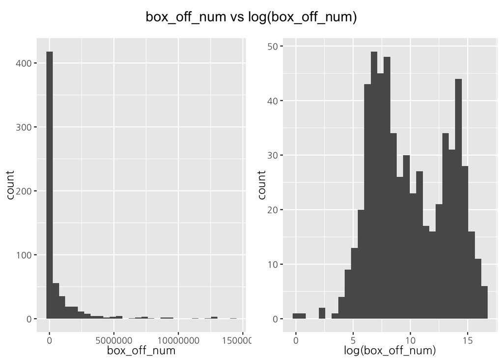

```r
hist1 <- train %>%
  select(box_off_num) %>%
  ggplot(aes(x = box_off_num)) +
  geom_histogram()

hist2 <- train %>%
  select(box_off_num) %>%
  ggplot(aes(x = log(box_off_num))) +
  geom_histogram()

title <- ggdraw() +
  draw_label('box_off_num vs log(box_off_num)')
plot_grid(title, plot_grid(hist1, hist2),
          ncol = 1, rel_heights = c(0.1, 1))
```

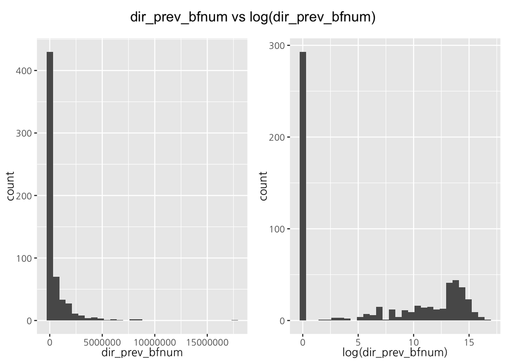

```r
hist3 <- train %>%
  select(dir_prev_bfnum) %>%
  ggplot(aes(x = dir_prev_bfnum)) +
  geom_histogram()

hist4 <- train %>%
  select(dir_prev_bfnum) %>%
  ggplot(aes(x = log(dir_prev_bfnum))) +
  geom_histogram()

title <- ggdraw() +
  draw_label('dir_prev_bfnum vs log(dir_prev_bfnum)')
plot_grid(title, plot_grid(hist3, hist4),
          ncol = 1, rel_heights = c(0.1, 1))
```

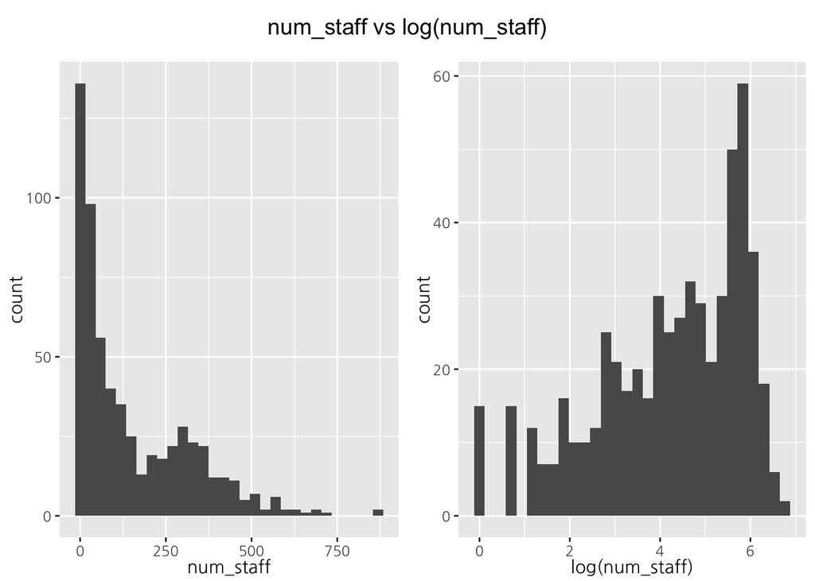

```r
hist5 <- train %>%
  select(num_staff) %>%
  ggplot(aes(x = num_staff)) +
  geom_histogram()

hist6 <- train %>%
  select(num_staff) %>%
  ggplot(aes(x = log(num_staff))) +
  geom_histogram()

title <- ggdraw() +
  draw_label('num_staff vs log(num_staff)')
plot_grid(title, plot_grid(hist5, hist6),
          ncol = 1, rel_heights = c(0.1, 1))
```

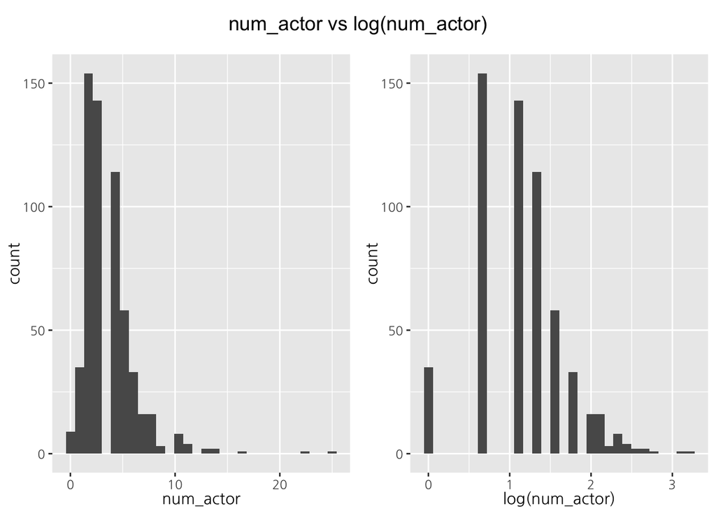

```r
hist7 <- train %>%
  select(num_actor) %>%
  ggplot(aes(x = num_actor)) +
  geom_histogram()

hist8 <- train %>%
  select(num_actor) %>%
  ggplot(aes(x = log(num_actor))) +
  geom_histogram()

title <- ggdraw() +
  draw_label('num_actor vs log(num_actor)')
plot_grid(title, plot_grid(hist7, hist8),
          ncol = 1, rel_heights = c(0.1, 1))
```

```r
train <- train %>%
  mutate(num_staff = ifelse(num_staff == 0, 1, num_staff),
         num_actor = ifelse(num_actor == 0, 1, num_actor)) %>%
  mutate(dir_prev_bfnum = log(dir_prev_bfnum),
         num_staff = log(num_staff),
         num_actor = log(num_actor),
         box_off_num = log(box_off_num))

test <- test %>%
  mutate(num_staff = ifelse(num_staff == 0, 1, num_staff),
         num_actor = ifelse(num_actor == 0, 1, num_actor)) %>%
  mutate(dir_prev_bfnum = log(dir_prev_bfnum),
         num_staff = log(num_staff),
         num_actor = log(num_actor))
```

가장 먼저, target 변수인 관람객 수에 대한 변수를 히스토그램으로 표현해보았다.

결과를 보면, 좌측 그래프가 전처리 수행 전 데이터인데, 오른쪽으로 꼬리가 긴 모양을 가지는 것을 볼 수 있다.

즉, 양의 왜도의 값을 가지면서 확률분포가 비대칭성을 갖고, 정규분포의 모양과 상당히 거리가 있다는 것을 알 수 있다.

따라서 이를 보완하기 위해 log를 취해서 비대칭성을 줄이고, 정규성을 높아지도록 한다. 최종으로도 log를 취한 변수로 활용한다.

이는 관람객 수 변수를 비롯하여, 해당 감독의 과거 영화에서의 평균 관람객 수, 스텝의 수, 배우의 수에도 동일하게 적용한다.

또한 최종적으로 target 변수는 다시 exponential을 취해줘서 마지막에는 값을 원상복구 시켜야 하는 것도 기억해야 한다.

```r
dist_median <- train %>%
  group_by(distributor) %>%
  summarise(median = median(box_off_num)) %>%
  arrange(median) %>%
  ungroup() %>%
  mutate(distributor_rank = 1:n()) %>%
  select(-median)

genre_mean <- train %>%
  group_by(genre) %>%
  summarise(mean = mean(box_off_num)) %>%
  arrange(mean) %>%
  ungroup() %>%
  mutate(genre_rank = 1:n()) %>%
  select(-mean)

train <- train %>%
  left_join(dist_median, by = 'distributor') %>%
  left_join(genre_mean, by = 'genre') %>%
  select(-title, -distributor, -director, -release_time, -genre)

test <- test %>%
  left_join(dist_median, by = 'distributor') %>%
  left_join(genre_mean, by = 'genre') %>%
  select(-distributor, -director, -release_time, -genre) %>%
  mutate(distributor_rank = ifelse(is.na(distributor_rank), 0, distributor_rank))

str(train)
```

```
## 'data.frame':    600 obs. of  9 variables:
##  $ time            : int  96 130 123 101 108 113 104 96 129 94 ...
##  $ screening_rat   : chr  "청소년 관람불가" "청소년 관람불가" "15세 관람가" "전체 관람가" ...
##  $ dir_prev_bfnum  : num  0 14 12.3 10.1 0 ...
##  $ dir_prev_num    : int  0 2 4 2 1 2 0 3 0 0 ...
##  $ num_staff       : num  4.51 5.96 5.84 3 5.53 ...
##  $ num_actor       : num  0.693 1.099 1.386 1.792 0.693 ...
##  $ box_off_num     : num  10.1 15.8 15.8 12.3 13.1 ...
##  $ distributor_rank: int  139 149 149 143 149 139 94 149 87 39 ...
##  $ genre_rank      : int  12 11 12 10 10 10 1 12 2 5 ...
```

```r
str(test)
```

```
## 'data.frame':    243 obs. of  9 variables:
##  $ title           : chr  "용서는 없다" "아빠가 여자를 좋아해" "하모니" "의형제" ...
##  $ time            : int  125 113 115 116 110 95 104 100 88 107 ...
##  $ screening_rat   : chr  "청소년 관람불가" "12세 관람가" "12세 관람가" "15세 관람가" ...
##  $ dir_prev_bfnum  : num  12.6 12.7 15.3 13.4 10.4 ...
##  $ dir_prev_num    : int  2 4 3 2 1 0 0 0 0 0 ...
##  $ num_staff       : num  5.72 5.62 6.04 6.01 5.94 ...
##  $ num_actor       : num  1.099 1.099 1.946 0.693 0 ...
##  $ distributor_rank: num  136 149 144 149 144 0 74 0 49 0 ...
##  $ genre_rank      : int  11 3 5 12 9 5 1 5 1 10 ...
```

다음은 distributor와 genre 변수를 처리해주도록 한다. 앞선 과정을 통해 기본적인 전처리는 마무리 되었다.

해당 변수 역시 범주형 변수이기 때문에 dummy coding 형태가 필요한데, 배급사와 장르 역시 영화 관람객 수에 중요한 변수이므로 이를 수치형으로 변환하고자 한다.

따라서 train 데이터에 대하여 배급사와 장르를 기준으로 group_by하고, 관람객 수의 중위값과 평균값으로 순서를 정렬해서 rank를 매겨준다.

결국 train 데이터에서 관람객 수가 많았던 배급사와 장르에 대해서는 distributor_rank와 genre_rank가 높을 것이다.

이를 test 데이터에도 적용해주고, train 데이터에서 없었던 경우에는 NA 값을 0으로 대체해주도록 한다.

```r
train <- train %>%
  mutate(over_12 = ifelse(screening_rat == '12세 관람가', 1, 0),
         over_15 = ifelse(screening_rat == '15세 관람가', 1, 0),
         over_19 = ifelse(screening_rat == '청소년 관람불가', 1, 0),
         all = ifelse(screening_rat == '전체 관람가', 1, 0)) %>%
  select(-screening_rat)

test <- test %>%
  mutate(over_12 = ifelse(screening_rat == '12세 관람가', 1, 0),
         over_15 = ifelse(screening_rat == '15세 관람가', 1, 0),
         over_19 = ifelse(screening_rat == '청소년 관람불가', 1, 0),
         all = ifelse(screening_rat == '전체 관람가', 1, 0)) %>%
  select(-screening_rat)

str(train)
```

```
## 'data.frame':    600 obs. of  12 variables:
##  $ time            : int  96 130 123 101 108 113 104 96 129 94 ...
##  $ dir_prev_bfnum  : num  0 14 12.3 10.1 0 ...
##  $ dir_prev_num    : int  0 2 4 2 1 2 0 3 0 0 ...
##  $ num_staff       : num  4.51 5.96 5.84 3 5.53 ...
##  $ num_actor       : num  0.693 1.099 1.386 1.792 0.693 ...
##  $ box_off_num     : num  10.1 15.8 15.8 12.3 13.1 ...
##  $ distributor_rank: int  139 149 149 143 149 139 94 149 87 39 ...
##  $ genre_rank      : int  12 11 12 10 10 10 1 12 2 5 ...
##  $ over_12         : num  0 0 0 0 0 0 0 0 0 0 ...
##  $ over_15         : num  0 0 1 0 1 1 0 0 0 1 ...
##  $ over_19         : num  1 1 0 0 0 0 0 1 0 0 ...
##  $ all             : num  0 0 0 1 0 0 1 0 1 0 ...
```

```r
str(test)
```

```
## 'data.frame':    243 obs. of  12 variables:
##  $ title           : chr  "용서는 없다" "아빠가 여자를 좋아해" "하모니" "의형제" ...
##  $ time            : int  125 113 115 116 110 95 104 100 88 107 ...
##  $ dir_prev_bfnum  : num  12.6 12.7 15.3 13.4 10.4 ...
##  $ dir_prev_num    : int  2 4 3 2 1 0 0 0 0 0 ...
##  $ num_staff       : num  5.72 5.62 6.04 6.01 5.94 ...
##  $ num_actor       : num  1.099 1.099 1.946 0.693 0 ...
##  $ distributor_rank: num  136 149 144 149 144 0 74 0 49 0 ...
##  $ genre_rank      : int  11 3 5 12 9 5 1 5 1 10 ...
##  $ over_12         : num  0 1 1 0 0 0 0 0 0 0 ...
##  $ over_15         : num  0 0 0 1 1 1 1 0 1 1 ...
##  $ over_19         : num  1 0 0 0 0 0 0 1 0 0 ...
##  $ all             : num  0 0 0 0 0 0 0 0 0 0 ...
```

이제 마지막으로 남은 관람 등급 변수인 screening_rat 변수를 확인하도록 한다.

해당 변수는 앞선 변수들과 동일하게 범주형 변수이지만, 크고 낮음을 평가하는 것이 어렵다.

따라서 원칙적으로 수행했던 것처럼 dummy coding을 수행하여 각각에 대한 변수들을 만들어주도록 한다.

그리고 최종적으로 구축된 데이터에 대하여 str 함수로 결과를 보면, 모든 변수가 수치형 변수로 모델이 작동할 수 있도록 셋팅되었다.

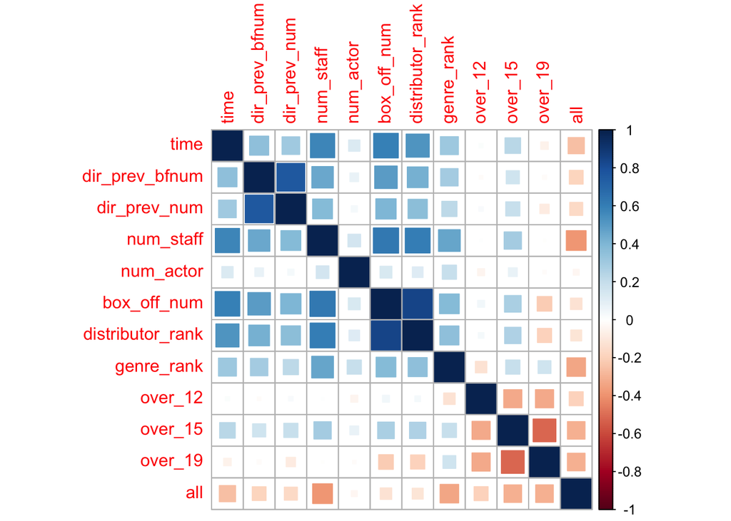

```r
train %>%
  cor(use = 'complete.obs') %>%
  corrplot(method = 'square')
```

또한 모든 변수들이 수치형이므로 상관계수에 대해 플랏을 그려보면, 우리의 Target 변수인 box_off_num과 다른 변수들 사이에 관계를 볼 수 있다.

가장 영향도가 높은 것은 distributor_rank이고, 스텝의 수나, 상영시간, 감독의 과거 영화에 대한 평균 관람객 수 등이 상관관계가 높은 것으로 나온다.

이렇게 구축된 데이터로부터 이제 다양한 알고리즘을 통해서 모델링을 수행해보도록 한다.

## 1. Decision Tree 모델을 활용하여 관객 수 예측

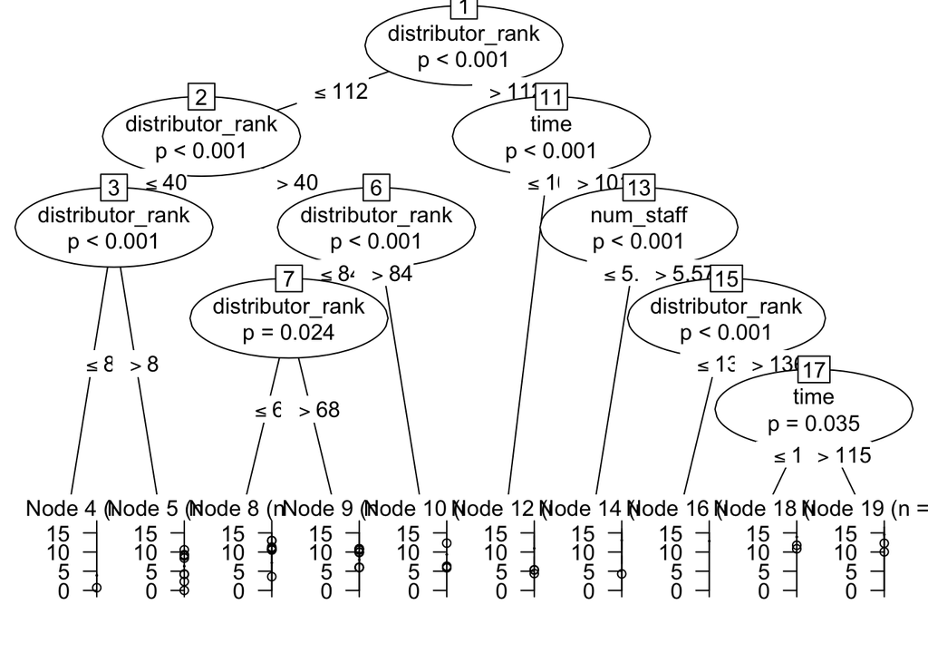

```r
train_col <- colnames(train)
train[train_col] <- sapply(train[train_col], as.numeric)
test_col <- colnames(test)[-1]
test[test_col] <- sapply(test[test_col], as.numeric)

DT_regressor <- ctree(box_off_num ~ ., data = train)
plot(DT_regressor)
```

```r
submission <- test %>%
  mutate(box_off_num = exp(predict(DT_regressor, test[, c(-1)]))) %>%
  select(title, box_off_num)

submission$box_off_num <- as.integer(submission$box_off_num)
# write.csv(submission, '/Users/paul/Desktop/submission.csv',
#           fileEncoding = 'utf-8', row.names = FALSE)
head(submission)
```

```
##                  title box_off_num
## 1          용서는 없다      412239
## 2 아빠가 여자를 좋아해      953716
## 3               하모니      953716
## 4               의형제     2287890
## 5            평행 이론      953716
## 6          회오리 바람          30
```

전처리가 완료된 데이터에 대하여 관객 수를 예측하는 모델을 Decision Tree 알고리즘으로 만들어본다.

일반적으로 트리 모델은 party 패키지 안에 tree, rpart, ctree 함수를 사용하고, 각각에 대한 특징은 다음과 같다.

- tree 함수: Binary Recursive Partitioning 방법을 사용하고, 불순도를 엔트로피 지수로 사용한다. 엔트로피는 0부터 1 사이의 값을 가지고, 1에 가까울수록 혼잡도가 높은 즉, 예측의 정확도가 낮은 상태이다. 따라서 엔트로피가 낮은 상태가 되도록 나무의 모양을 생성한다.
- rpart 함수: CART 방법을 사용하는 것으로, 전체 데이터에 대해 반복해서 두 개의 자식 노드를 생성하기 위해 모든 예측 변수를 사용한다. 이 때는 Gini-index가 작아지는 방향으로 움직이도록 모델을 생성한다.
- ctree 함수: Unbiased Recursive Partitioning Based on Permutation 방법을 사용하여 p-test를 거친 significnace를 기준으로 가지치기를 할 변수를 결정하여 biased 될 위험이 낮고, 별도로 Pruning을 할 필요가 없다. 하지만 입력 변수의 레벨이 31개까지로 제한되어 있는 특징이 있다.

[figure not shown]

이를 통해 데이콘 홈페이지에서 결과를 확인해보도록 한다.

그 결과는 **553,633 정도로 41등** 정도로 랭크된 것을 확인했다. 다음은 Bagging 알고리즘을 활용해보도록 한다.

## 2. Bagging 모델을 활용하여 관객 수 예측

```r
output_df <- data_frame()
for (num in seq(10, 50, 10)){
  for (method in c('cv', 'repeatedcv')){
    control <- trainControl(method = method, number = num)
    output <- train(box_off_num ~ ., data = train, method = 'treebag', trControl = control)
    output$result$num <- num
    output$result$method <- method
    output_df <- rbind(output_df, output$result)
  }
}

target <- output_df %>% arrange(RMSE) %>% filter(row_number() == 1)
control <- trainControl(method = target$method, number = target$num)
Bag_regressor <- train(box_off_num ~ ., data = train, method = 'treebag', trControl = control)

submission <- test %>%
  mutate(box_off_num = exp(predict(Bag_regressor, test[, c(-1)]))) %>%
  select(title, box_off_num)

submission$box_off_num <- as.integer(submission$box_off_num)
# write.csv(submission, '/Users/paul/Desktop/submission.csv',
#           fileEncoding = 'utf-8', row.names = FALSE)
head(submission)
```

```
##                  title box_off_num
## 1          용서는 없다      882134
## 2 아빠가 여자를 좋아해     1033473
## 3               하모니     1033473
## 4               의형제     1033473
## 5            평행 이론      977473
## 6          회오리 바람         138
```

두번째로는 Bagging 알고리즘을 활용하여 관객 수를 예측해보도록 한다.

adabag 패키지의 bagging 함수와 caret 패키지의 train 함수에서 method를 ’treebag’로 활용하여 Bagging 모델을 만들 수 있다.

먼저 trainControl 함수에서 교차검증 및 반복교차검증 방법으로 number의 개수를 수정하면서 RSME이 가장 최저가 되는 모델 파라미터를 확인한다.

그리고 나서는 해당 모델로 최종 Bagging 모델을 만들어서 데이콘에서 test 데이터에 대한 결과를 확인한다.

[figure not shown]

앞선 Decision Tree 보다는 소폭 결과가 상승한 것을 확인할 수 있다. 다음은 Random Forest 알고리즘이다.

## 3. Random Forest 모델을 활용하여 관객 수 예측

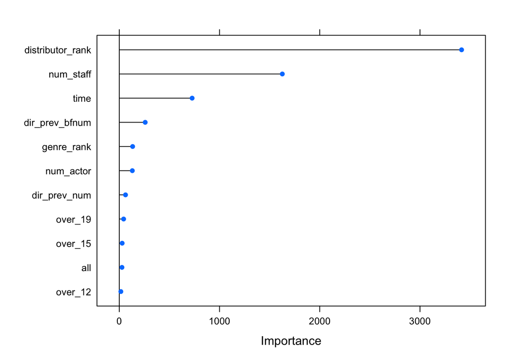

```r
control <- trainControl(method = 'cv', search = 'grid', number = 10)
RF_regressor <- train(box_off_num ~ ., data = train, method = 'rf', trControl = control)

importance <- varImp(RF_regressor, scale=FALSE)
plot(importance)
```

```r
submission <- test %>%
  mutate(box_off_num = exp(predict(RF_regressor, test[, c(-1)]))) %>%
  select(title, box_off_num)

submission$box_off_num <- as.integer(submission$box_off_num)
# write.csv(submission, '/Users/paul/Desktop/submission.csv',
#           fileEncoding = 'utf-8', row.names = FALSE)
head(submission)
```

```
##                  title box_off_num
## 1          용서는 없다     1297121
## 2 아빠가 여자를 좋아해      778750
## 3               하모니     1185001
## 4               의형제     1470665
## 5            평행 이론      931358
## 6          회오리 바람          95
```

이번에는 Random Forest 모델을 활용하여 관객의 수를 예측해보도록 한다.

위와 동일하게 caret 패키지에서 method를 ’rf’로 바꿔서 Random Forest에 대한 결과를 확인해보도록 한다.

K-Fold 교차검증을 활용하여 모델을 만들어보고자 한다.

K-Fold 교차검증은 train 데이터를 K개로 나누고, K-1개 데이터셋으로 학습하여 나머지 1개 데이터셋에 평가하는 과정을 K번 반복하여 수행한다.

그리고 K개의 모델이 만들고, 각 모델의 MSE 값의 평균으로 해당 모델의 MSE를 결정한다.

보통 5-Fold나 10-Fold를 많이 사용하는데, 두 개 모두 해보았더니 K를 10으로 하는 것이 결과가 더 좋았다.

이렇게 만들어진 모델에 대하여 feature importance 즉, 변수의 중요도도 확인해본다.

varImp 함수를 통해서 Random Forest 모델에서의 Importance를 출력하면 위와 같음을 확인할 수 있다.

변수 중요도는 말 그대로 종속 변수를 예측하는데 사용되는 각각의 독립 변수들이 얼마나 중요한지를 확인하는 지표이다.

일반적으로 Random Forest는 지니 평균 감소량으로 변수 중요도를 판단하는데, 이는 불순도를 가장 많이 감소시켜주는 독립변수를 활용하기 때문이다.

따라서 변수 중요도를 통해서 각 독립 변수들의 상대적인 중요도를 한번에 확인할 수 있다.

이 결과를 통해서 보면, 위에서 확인했던 상관계수 결과와 거의 유사하게 나오는 것을 알 수 있다.

distributor_rank, num_staff, time 등의 변수가 예측에 긍정적인 영향을 미치고 있으며, 관람객 등급 변수들은 크게 의미가 없는 것을 알 수 있다.

[figure not shown]

최종적으로 데이콘 홈페이지에서 해당 모델의 결과를 확인해보도록 한다. 그 결과는 **473,867 정도로 2등** 정도로 랭크된 것을 확인했다.

앞선 Decision Tree와 Bagging 보다는 결과가 많이 상승한 것을 확인할 수 있다. 다음은 마지막인 XGBoost 알고리즘이다.

## 4. XGBoost 모델을 활용하여 관객 수 예측

일반적으로 XGBoost 알고리즘은 아래와 같이 3가지의 주요한 파라미터가 있다.

1. 도구의 모양을 결정하는 일반 파라미터(General Parameter)
   - booster: 어떤 부스터 구조를 사용할지 결정 -> gbtree, gblinear, dart
   - nthread: 몇 개의 쓰레드를 동시에 처리할지 결정 -> default는 가능한 많이
   - num_feature: feature 차원의 숫자를 정해야 하는 경우 옵션 셋팅 -> default는 가능한 많이
2. 트리마다 가지치는 용도로 활용되는 부스터 파라미터(Booster Parameter)
   - eta: Learning rate로 매 부스팅 스탭마다 weight를 주어 부스팅 과정에서 과적합이 되지 않도록 한다.
   - gamma: 이 값이 커지면, 트리의 깊이가 줄어들어서 보수적인 모델이 된다. default는 0이다.
   - max_depth: 한 트리의 maximum depth로, 숫자를 키울수록 모델이 복잡해져서 과적합 우려가 있다.
   - lambda(L2 정규화): L2 Regularization에 붙는 weights이고, 숫자가 커질수록 보수적인 모델이 된다.
   - alpha(L1 정규화): L1 Regularization에 붙는 weights이고, 숫자가 클수록 보수적인 모델이 된다.
3. 최적화 퍼포먼스를 위한 학습 과정 파라미터(Learning Task Parameter)
   - objective: 목적 함수로, linear-regression, binary-logistic classification, poison regression 등 다양하다.
   - eval_metric: 모델의 평가 함수를 조정하는 함수로 RMSE, logloss, map 등이 있다.

```r
grid <- expand.grid(nrounds = 10000,
                    eta = seq(0.01, 0.3, 0.05),
                    max_depth = seq(1:8),
                    gamma = seq(0, 5, 1),
                    colsample_bytree = 1,
                    min_child_weight = 1,
                    subsample = 1)

control <- trainControl(method = "cv", search = 'grid', number = 10)
xgb_regressor <- train(box_off_num ~ ., data = train,
                       trControl = control, tuneGrid = grid, method = 'xgbTree')

submission <- test %>%
  mutate(box_off_num = exp(predict(xgb_regressor, test[, c(-1)]))) %>%
  select(title, box_off_num)

submission$box_off_num <- as.integer(submission$box_off_num)
# write.csv(submission, '/Users/paul/Desktop/submission.csv',
#           fileEncoding = 'utf-8', row.names = FALSE)
head(submission)
```

```
##                  title box_off_num
## 1          용서는 없다      994992
## 2 아빠가 여자를 좋아해     1607639
## 3               하모니     1240658
## 4               의형제     2317868
## 5            평행 이론     1048191
## 6          회오리 바람          10
```

위에서 이야기 했던 것처럼 XGBoost는 셋팅해야 하는 parameter가 상당히 많다.

따라서 이를 여러가지 케이스로 확인하기 위하여 Grid Search를 수행해보도록 한다.

Grid Search 방법은 탐색할 변수들의 조합을 만들어서 이들을 모델에 적용하면서 가장 최적의 파라미터를 찾는 방법이다.

그래서 eta, max_depth, gamma 등에 대한 변수들을 몇 가지 케이스로 나눠서 변수를 셋팅해주었다.

그 후에는 Random Forest와 동일하게 trainControl을 주고, xgbTree 즉, XGBoost 알고리즘의 결과를 확인한다.

이를 통해 나온 최종 결과는 아래와 같음을 확인할 수 있다.

[figure not shown]

최종적으로 데이콘 홈페이지에서 XGBoost 모델의 결과를 확인해보았고, **497,784**가 나오는 것을 확인할 수 있었다.

비록 앞선 Random Forest 보다는 조금 감소한 성능이긴 하지만, 그래도 상위권에 소속되는 것을 확인할 수 있었다.